# Brain stroke

#### Ninth: Gain ratio (C5.0) - Testing 80:20

```r
predictions6 <- predict(c50_model, newdata = test80, type = "class")
actual_labels6 <- test80$stroke
```

#### Tenth: Model Evaluation and Selection 80:20 for Gain ratio

```r
confusion_matrix <- table(actual_labels6, predictions6)
print(confusion_matrix)
```

```
##               predictions6
## actual_labels6   0   1
##              0 675 271
##              1 130 816
```

```r
TP <- confusion_matrix[1, 1]
TN <- confusion_matrix[2, 2]
FP <- confusion_matrix[2, 1]
FN <- confusion_matrix[1, 2]

accuracy <- ((TP + TN) / sum(confusion_matrix)) *100
precision <- (TP / (TP + FP) )*100
sensitivity <- (TP / (TP + FN) )*100
specificity <- (TN / (TN + FP) )*100
cat("Accuracy:", accuracy, "%\n")
```

```
## Accuracy: 78.8055 %
```

```r
cat("Precision:", precision, "%\n")
```

```
## Precision: 83.85093 %
```

```r
cat("Sensitivity (Recall):", sensitivity, "%\n")
```

```
## Sensitivity (Recall): 71.35307 %
```

```r
cat("Specificity:", specificity, "%\n")
```

```
## Specificity: 86.25793 %
```

**findings:**

Upon examining the Information Gain Ratio tree, it is evident that there are eight rules corresponding to the eight leaf nodes. Some notable rules extracted from the tree include:

- IF age<=0.573 THEN stroke=no
- IF age>0.573 AND age>0.817 THEN stroke=yes

#### First: Splitting our data 75:25

```r
set.seed(2)
traindata75 <- createDataPartition(datasetbrainstroke$stroke, p=0.75,
                                 list=FALSE, times=1)
train75 <- datasetbrainstroke[traindata75,]
test75 <- datasetbrainstroke[-traindata75,]
# Checking that both the training and testing sets have the same label proportions.
prop_train75 <- train75 %>% select(stroke) %>% group_by(stroke) %>% summarize(n=n()) %>%
mutate(pct=round(prop.table(n), 2))

prop_test75 <- test75 %>% select(stroke) %>% group_by(stroke) %>% summarize(n=n()) %>%
mutate(pct=round(prop.table(n), 2))

prop_train75
```

| stroke | n | pct |
| --- | --- | --- |
| 0 | 3550 | 0.5 |
| 1 | 3550 | 0.5 |

```r
prop_test75
```

| stroke | n | pct |
| --- | --- | --- |
| 0 | 1183 | 0.5 |
| 1 | 1183 | 0.5 |

#### Second: Information Gine (ID3) - Tree model 75:25

```r
train75$stroke <- as.factor(train75$stroke)
tree_model <- rpart(stroke ~ ., data = train75, method = "class", parms = list(split = "information"))
print(tree_model)
```

```
## n= 7100
##
## node), split, n, loss, yval, (yprob)
##       * denotes terminal node
##
##  1) root 7100 3550 0 (0.50000000 0.50000000)
##    2) age< 0.1800373 2226  214 0 (0.90386343 0.09613657) *
##    3) age>=0.1800373 4874 1538 1 (0.31555191 0.68444809)
##      6) age< 1.062543 2209 1015 1 (0.45948393 0.54051607)
##       12) age< 0.5771646 870  366 0 (0.57931034 0.42068966)
##         24) hypertension< 0.5 691  251 0 (0.63675832 0.36324168) *
##         25) hypertension>=0.5 179   64 1 (0.35754190 0.64245810) *
##       13) age>=0.5771646 1339  511 1 (0.38162808 0.61837192)
##         26) smoking_status< 2.5 592  292 0 (0.50675676 0.49324324)
##           52) smoking_status>=1.5 296   90 0 (0.69594595 0.30405405) *
##           53) smoking_status< 1.5 296   94 1 (0.31756757 0.68243243) *
##         27) smoking_status>=2.5 747  211 1 (0.28246319 0.71753681) *
##      7) age>=1.062543 2665  523 1 (0.19624765 0.80375235) *
```

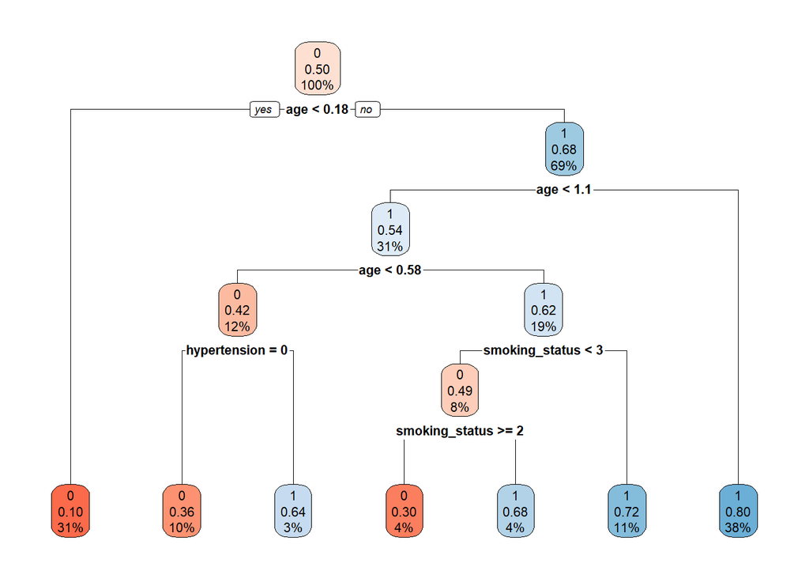

```r
rpart.plot(tree_model, box.palette = "RdBu")
```

#### Third: Information Gine (ID3) - Testing 75:25

```r
predictions7 <- predict(tree_model, newdata = test75, type = "class")
actual_labels7 <- test75$stroke
```

#### Fourth: Model Evaluation and Selection 75:25 for ID3

```r
confusion_matrix <- table(actual_labels7, predictions7)
print(confusion_matrix)
```

```
##               predictions7
## actual_labels7   0   1
##              0 866 317
##              1 200 983
```

```r
TP <- confusion_matrix[1, 1]
TN <- confusion_matrix[2, 2]
FP <- confusion_matrix[2, 1]
FN <- confusion_matrix[1, 2]

accuracy <- ((TP + TN) / sum(confusion_matrix)) *100
precision <- (TP / (TP + FP) )*100
sensitivity <- (TP / (TP + FN) )*100
specificity <- (TN / (TN + FP) )*100
cat("Accuracy:", accuracy, "%\n")
```

```
## Accuracy: 78.14877 %
```

```r
cat("Precision:", precision, "%\n")
```

```
## Precision: 81.23827 %
```

```r
cat("Sensitivity (Recall):", sensitivity, "%\n")
```

```
## Sensitivity (Recall): 73.20372 %
```

```r
cat("Specificity:", specificity, "%\n")
```

```
## Specificity: 83.09383 %
```

**findings:**

#### Fifth: Gini index (CART) - Tree model 75:25

```r
tree_model <- rpart(stroke ~ ., data = train75, method = "class", parms = list(split = "gini"))
print(tree_model)
```

```
## n= 7100
##
## node), split, n, loss, yval, (yprob)
##       * denotes terminal node
##
##  1) root 7100 3550 0 (0.5000000 0.5000000)
##    2) age< 0.4447888 2777  434 0 (0.8437162 0.1562838) *
##    3) age>=0.4447888 4323 1207 1 (0.2792043 0.7207957)
##      6) age< 1.062543 1658  684 1 (0.4125452 0.5874548)
##       12) bmi< -0.1838126 291  108 0 (0.6288660 0.3711340) *
##       13) bmi>=-0.1838126 1367  501 1 (0.3664960 0.6335040) *
##      7) age>=1.062543 2665  523 1 (0.1962477 0.8037523) *
```

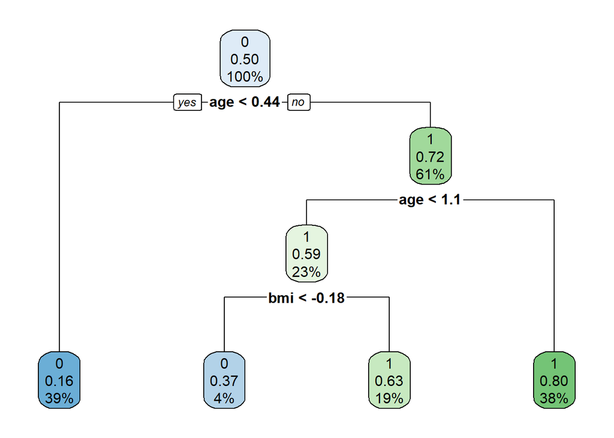

```r
rpart.plot(tree_model)
```

#### Sixth: Gini index (CART) - Testing 75:25

```r
predictions8 <- predict(tree_model, newdata = test75, type = "class")
actual_labels8 <- test75$stroke
```

#### Seventh: Model Evaluation and Selection 75:25 for Gini index

```r
confusion_matrix <- table(actual_labels8, predictions8)
print(confusion_matrix)
```

```
##               predictions8
## actual_labels8   0   1
##              0 824 359
##              1 187 996
```

```r
TP <- confusion_matrix[1, 1]
TN <- confusion_matrix[2, 2]
FP <- confusion_matrix[2, 1]
FN <- confusion_matrix[1, 2]

accuracy <- ((TP + TN) / sum(confusion_matrix)) *100
precision <- (TP / (TP + FP) )*100
sensitivity <- (TP / (TP + FN) )*100
specificity <- (TN / (TN + FP) )*100
cat("Accuracy:", accuracy, "%\n")
```

```
## Accuracy: 76.92308 %
```

```r
cat("Precision:", precision, "%\n")
```

```
## Precision: 81.50346 %
```

```r
cat("Sensitivity (Recall):", sensitivity, "%\n")
```

```
## Sensitivity (Recall): 69.65342 %
```

```r
cat("Specificity:", specificity, "%\n")
```

```
## Specificity: 84.19273 %
```

**findings:**

#### Eighth: Gain ratio (C5.0) - Tree model 75:25

[figure not shown]

```r
# Convert stroke to a factor variable
train75$stroke <- as.factor(train75$stroke)

# Set C5.0 control parameters
c5_control <- C5.0Control(winnow = TRUE, CF = 0.01, minCases = 40)

# Create a formula for the C5.0 model
myFormula <- stroke ~ age + hypertension +ever_married+avg_glucose_level

# Fit the C5.0 decision tree model
c50_model <- C5.0(myFormula, data = train75, control = c5_control)

# Plot the C5.0 decision tree
plot(c50_model, control = list(maxdepth = 3))
```

#### Ninth: Gain ratio (C5.0) - Testing 75:25

```r
predictions9 <- predict(c50_model, newdata = test75, type = "class")
actual_labels9 <- test75$stroke
```

#### Tenth: Model Evaluation and Selection 75:25 for Gain ratio

```r
confusion_matrix <- table(actual_labels9, predictions9)
print(confusion_matrix)
```

```
##               predictions9
## actual_labels9    0    1
##              0  820  363
##              1  168 1015
```

```r
TP <- confusion_matrix[1, 1]
TN <- confusion_matrix[2, 2]
FP <- confusion_matrix[2, 1]
FN <- confusion_matrix[1, 2]

accuracy <- ((TP + TN) / sum(confusion_matrix)) *100
precision <- (TP / (TP + FP) )*100
sensitivity <- (TP / (TP + FN) )*100
specificity <- (TN / (TN + FP) )*100
cat("Accuracy:", accuracy, "%\n")
```

```
## Accuracy: 77.55706 %
```

```r
cat("Precision:", precision, "%\n")
```

```
## Precision: 82.99595 %
```

```r
cat("Sensitivity (Recall):", sensitivity, "%\n")
```

```
## Sensitivity (Recall): 69.3153 %
```

```r
cat("Specificity:", specificity, "%\n")
```

```
## Specificity: 85.79882 %
```

**findings:**

After using the model to classify the data, things look good. The model did well in sorting out the different groups.This means the model is doing what we wanted it to do. It’s like a solid base for making smart choices, and it gives us useful info for future projects using data.

# 6. Evaluation and comparision

## **classification:**

**Information Gain:**

[output not shown]

**Gini Index:**

[output not shown]

**Information Gain Ratio:**

[output not shown]

## Clustering:

| Cluster size | k=2(Best) | k=3 | k=4 |
| --- | --- | --- | --- |
| Average S ilhouette width for each cluster | cluster1 = 0.39 cluster2 = 0.30 | cluster1 = 0.60 cluster2 = 0.17 cluster3 = 0.20 | cluster1 = 0.20 cluster2 = 0.19 cluster3 = 0.15 cluster4 = 0.58 |
| Average S ilhouette width for all clusters | 0.33 | 0.25 | 0.24 |
| Total w i t h i n-cluster sum of square | 18358.56 | 14981.07 | 12844.35 |
| BCubed precision | 0.9071407 | 0.909903 | 0.9085269 |
| BCubed recall | 0.6096986 | 0.410234 | 0.2755282 |
| V i s u alization | all of the figures is shown above | all of the figures is shown above | all of the figures is shown above |

# 7. Findings

## 1-classification findings:

Considering our objective of advancing medical understanding, devising ways to prevent strokes, improving treatment options, and lessening the impact of brain strokes, the qualities of Information Gain Ratio position it as a strong contender for meeting these goals.

## 2- clustering findings:

2- clustering findings

For Clustering, we used K-means clustering with 3 different K to find the optimal number of clusters, and we concluded the following results:

Silhouette Width: Silhouette width measures how similar an object is to its own cluster (cohesion) compared to other clusters (separation).

- For k=2, the average silhouette width is 0.33, with cluster1 having a width of 0.39 and cluster2 having a width of 0.30.
- For k=3, the average silhouette width is 0.25, with cluster1 having a width of 0.60, cluster2 having a width of 0.17, and cluster3 having a width of 0.20.
- For k=4,the average silhouette width is 0.24, with cluster1 having a width of 0.20, cluster2 having a width of 0.19, cluster3 having a width of 0.15, and cluster4 having a width of 0.58.

For k=2, the average silhouette width is 0.33, suggesting well-defined clusters. For k=3, the average silhouette width decreases to 0.25, indicating less distinct clusters. For k=4, the average silhouette width is 0.24, with cluster1 and cluster4 having higher individual widths.

The silhouette width provides insights into the cohesion and separation of clusters. A higher average silhouette width indicates better-defined clusters. In this case, the highest average silhouette width is observed for k=2, suggesting that a two-cluster solution might be optimal.

Total Within-Cluster Sum of Squares: This measures the compactness of the clusters. Smaller values indicate tighter clusters.

- For k=2, the WSS is 18358.56, implying a certain level of compactness in the two clusters.
- For k=3, the WSS decreases to 14981.07, suggesting improved compactness as the number of clusters increases.
- For k=4, the WSS further decreases to 12844.35, indicating even tighter clusters with the introduction of an additional cluster.

BCubed Precision and Recall: BCubed precision and recall are metrics used to evaluate the quality of clustering based on ground truth labels. For k=2, precision is 0.9071407, and recall is 0.6096986. For k=3, precision is 0.909903, and recall is 0.410234. For k=4, precision is 0.9085269, and recall is 0.2755282.

For k=2, precision is high at 0.9071407, and recall is 0.6096986. For k=3, precision is slightly higher at 0.909903, but recall decreases to 0.410234. For k=4, precision is similar to k=2, but recall decreases further to 0.2755282.

Visualization: The visualization of clusters shows that K=2 is a better candidate for optimal number of clusters since it has the least overlap.

K=2 vs. K=3: K=2 shows higher silhouette width, suggesting better-defined clusters. BCubed recall is also higher for k=2, indicating that more relevant instances are captured in this configuration. Depending on the importance of precision, k=3 has slightly higher precision but at the cost of lower recall.

K=4: K=4 has lower silhouette width, lower recall, and precision comparable to k=2. The decrease in recall may indicate a less effective clustering in capturing all relevant instances.

Conclusion: k=2 seems to be a strong candidate for the optimal number of clusters. It exhibits higher silhouette width and better BCubed recall, aligning well with the goal of clustering to capture relevant instances.

Problem Solutions (Extracted Information): After applying clustering, the data has been grouped into distinct clusters, providing a solution for organizing and understanding the underlying patterns in the data.

In summary, the comprehensive analysis supports the choice of k=2 as the optimal number of clusters.

Our dataset contains information related to individuals’ health, encompassing features such as gender, age, hypertension, heart disease, marital status, work type, residence type, average glucose level, body mass index (BMI), smoking status, and whether or not a stroke has occurred (the target variable).

**Let’s discuss whether this dataset is more suitable for classification or clustering:**

**Classification:**

Classification is a supervised learning task where the goal is to predict a specific category or label for each data point. In our dataset, the target variable is whether a stroke occurred (1) or not (0). If we aim to predict whether an individual is at risk of having a stroke based on the given features, this is a binary classification problem. The dataset is labeled, signifying a clear outcome variable (stroke or no stroke), making it suitable for a classification model.

**Clustering:**

Clustering is an unsupervised learning task where the goal is to group similar data points together based on some similarity metric. Our dataset on brain Stroke doesn’t seem particularly well-suited for clustering because it lacks a clear indication of groups or clusters that the model should identify. Clustering is more applicable when you have unlabeled data and aim to discover inherent patterns or groupings.

**In summary, our dataset is better suited for a classification task. We can use machine learning algorithms, such as logistic regression, decision trees, or support vector machines, to build a model that predicts whether an individual is likely to have a stroke based on the provided features.**

# 8. References

[1]C. Guild, “RPubs - Classification and Regression Trees (CART) in R,” RPubs, Aug. 28, 2021. https://rpubs.com/camguild/803096 (accessed Dec. 01, 2023).

[2]K. Mazidi, “RPubs - Data Mining: Classification with Decision Trees,”RPubs. https://rpubs.com/kjmazidi/195428 (accessed Dec. 01, 2023).

[3]M. P. Frushicheva, “RPubs - k-means clustering,” rpubs, Aug. 11, 2016. https://rpubs.com/violetgirl/201598 (accessed Dec. 01, 2023).

[4]J. SOFT TECH, “Brain Stroke Dataset,” Kaggle, Aug. 04, 2022. https://www.kaggle.com/datasets/jillanisofttech/brain-stroke-dataset (accessed Dec. 01, 2023).